# NTSB Aviation Data - Exploratory Data Analysis

Team 9

2023-02-20

# Intro/Explanation

Exploratory data analysis (EDA) is a process of examining and analyzing data to extract insights and identify patterns. In this case, we have a dataset of aircraft incidents which have been reported around the Globe. For our purposes, however, we need to filter it down to United States only. Here are some steps for conducting an EDA on this dataset:

Check the data types and missing values:

First, we should check the data types of each column to make sure they are correct. We can also check if there are any missing values in the dataset. Explore the distributions of the numerical columns:

We can use histograms or box plots to visualize the distributions of the numerical columns (Latitude and Longitude). This can help us understand the range of values and identify any potential outliers.

Explore the categorical columns:

We can create bar charts or pie charts to visualize the frequency distribution of the categorical columns (ICAO.Code, IATA.Code, Airport.Name, City, and Country). This can help us understand the distribution of airports across different regions.

Look for correlations:

We can use scatter plots or correlation matrices to identify any correlations between the numerical columns (Latitude and Longitude). This can help us understand the relationships between the variables and identify any potential patterns.

Identify any potential outliers or anomalies:

We can use box plots or scatter plots to identify any potential outliers or anomalies in the data. This can help us understand if there are any unusual values that might be errors or require further investigation.

Compare airports:

We can create separate visualizations for the airports to compare their distributions and identify any differences or similarities.

Overall, an EDA can help us understand the characteristics of the dataset and identify any potential issues or opportunities for further analysis.

# Data Cleaning/Reformatting

Before doing any analysis on our dataset, we altered the table to remove null values and filter the data for a number of specifications given by our liason. We also changed the granularity of several columns for analysis purposes later on.

## Changelog:

-Store only US data

-Store only data from post 2001

-Store only data about Airplanes

-Remove na values from make and model (DROPS about 20 rows)

-Remove aircraft which have been designated as commercial aircraft (using additional dataset)

-Remove aircraft with 40 or more passengers total (Counting inj, non-inj)

-Fill na values for long, lat using Global Airport Database csv -Reformat $Location to include city name and country

-Remove Columns (Publication.Date, Schedule, Accident.Number, Registration.Number, Air.carrier, Investigation.Type)

-Reformat Amateur.built column to “Y/N” format -Remove Nulls from Amateur.built column

-Remove Nulls and unknown values from Aircraft.damage column

-Remove Nulls and unknown from Engine.Type column

-Calculate severity index rating for each indedent and then calculate rating for each US airport that is in the dataset

-Reformat Event.Date to include Year and Month as seperate columns

-Export Final Cleaned Data Set

# Exploratory Data Analysis

Now that the dataset is cleaned/formatted in a manageable format, EDA can begin.

We start by comparing the different categorical vs continuous variables in our dataset using a correlation matrix. Larger circles indicate strong correlation, red means negative correlation, blue means positive.

## Correlation Matrix

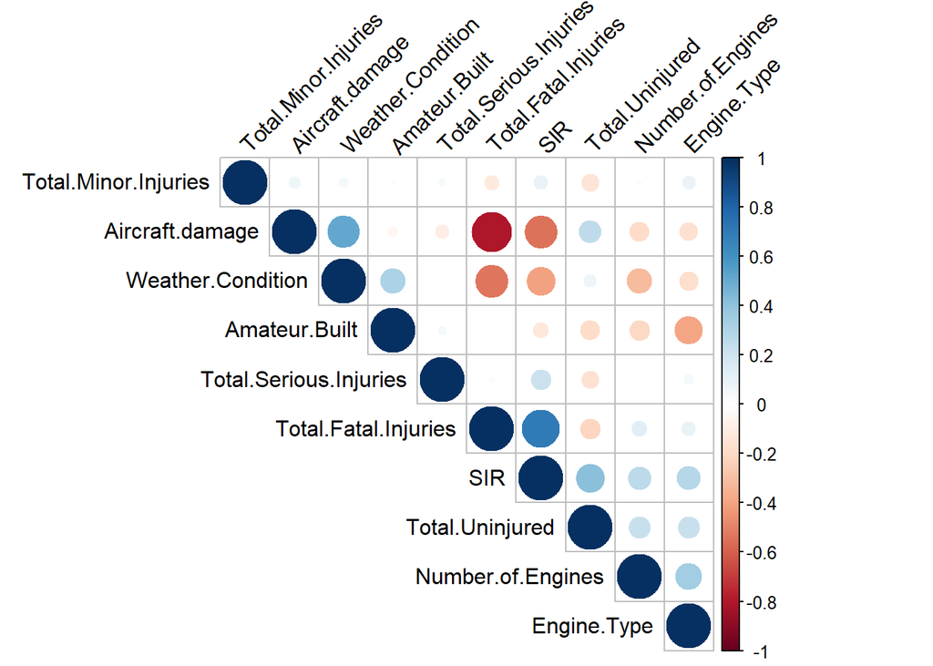

From a quick glance at the correlation matrix above, Weather condition has a strong correlation to total Fatal injuries, as well as aircraft damage. SIR has a high relation to Total Fatal injuries, which makes sense because the Severity index rating is highly influenced by fatal injuries in the equation.

## Accident Hotspot Map

Next, we will compare incident severity/count by location using a heatmap of the United States to identify trends and key locations where accidents have occured using primarily longitude/latitude.

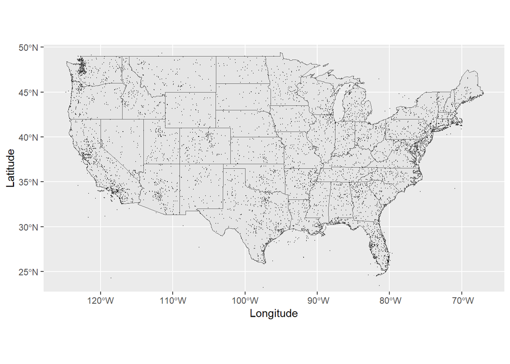

This initial hotspot map shows us that there are accident hotspots in major metropolitan areas across the United States. Some of the big hotspots of accidents along the west coast are in Seattle, Portland, the Bay Area and generally, southern California. We can also see some big hotspots in Chicago, the New York/New Jersey area and all over southern Florida.

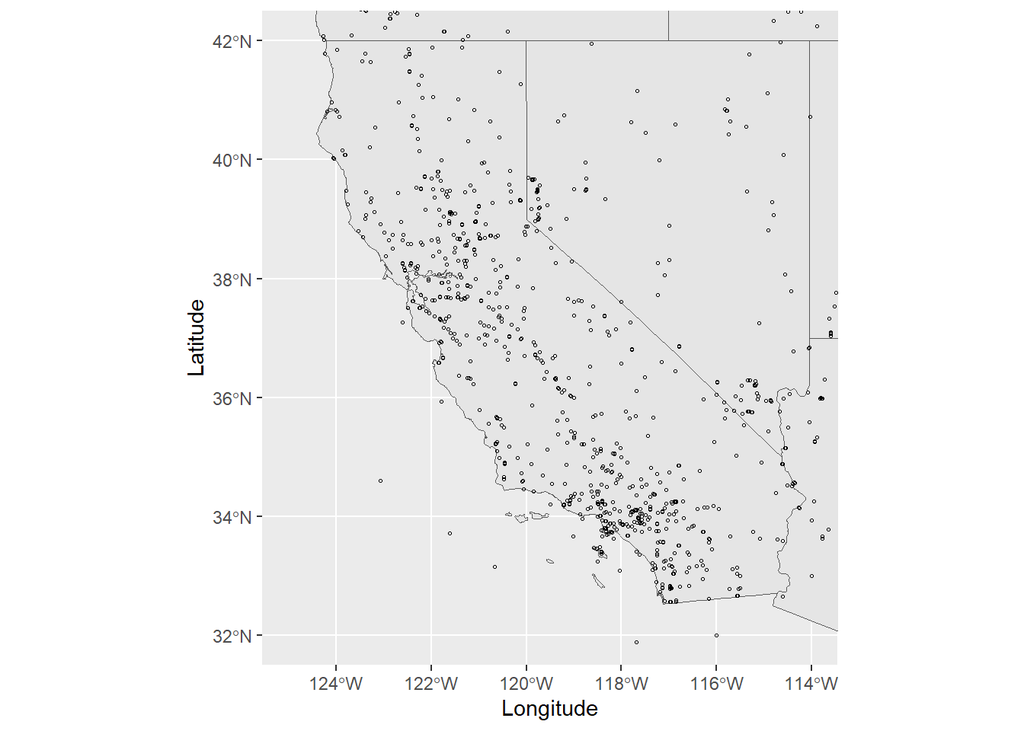

When taking a look at California individually we can see a significant cluster in the greater los angeles area.

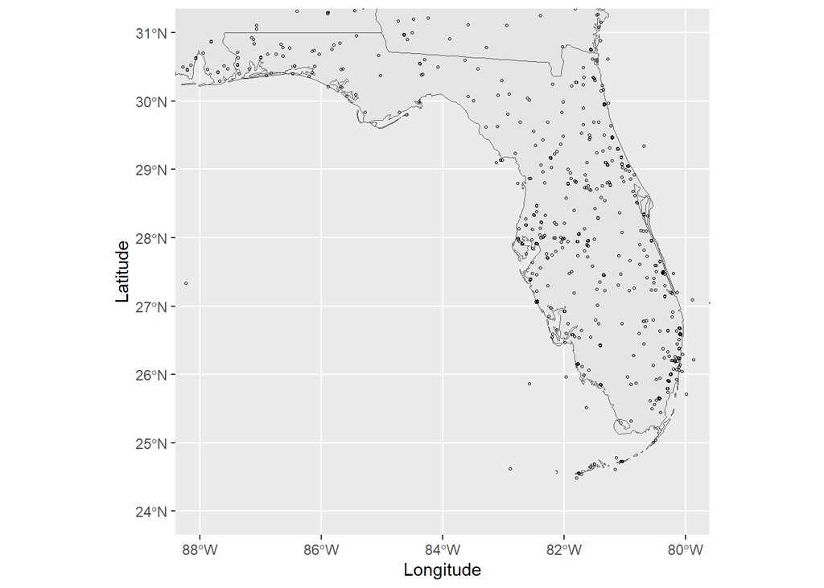

Florida has incidents spread all across the state, with a small hotspot in the Miami area.

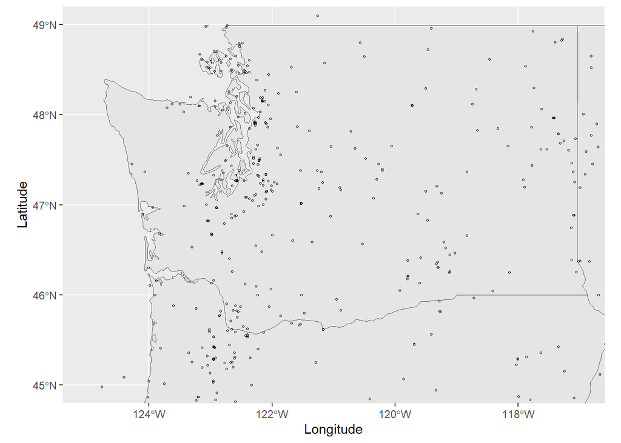

Here we can see more incidents clustered around the puget sound in Washington.

## Counts of Key Variables

Next, we will dive further into our exploratory analysis by visualizing the number of accidents against different key variables to get an understanding of which variables may be significant.

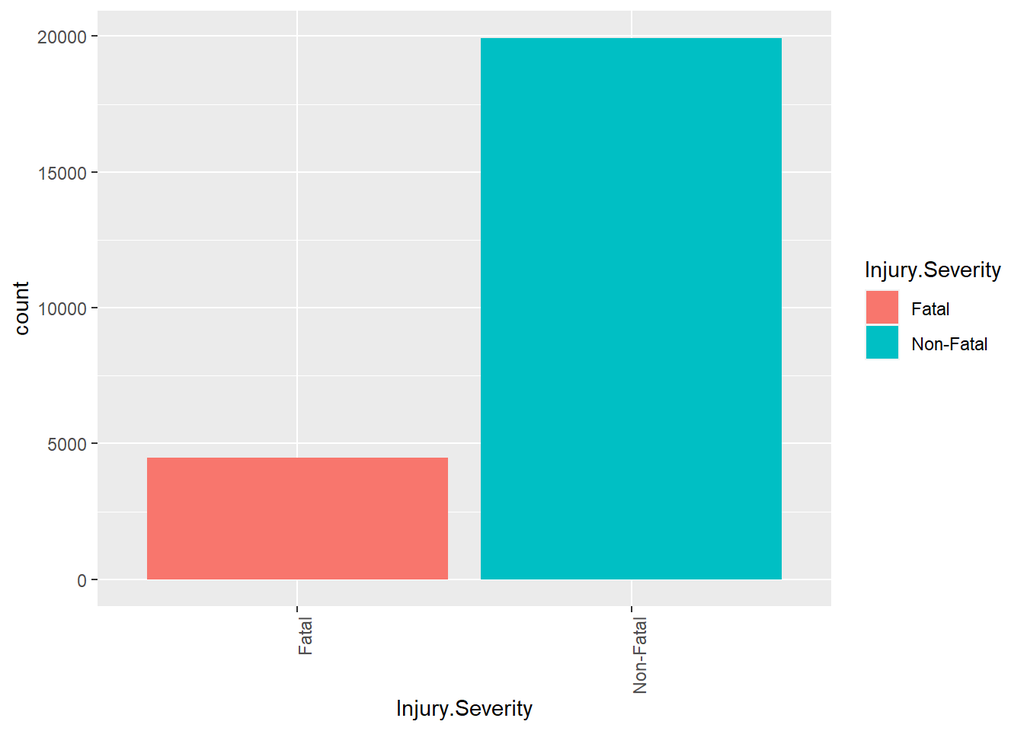

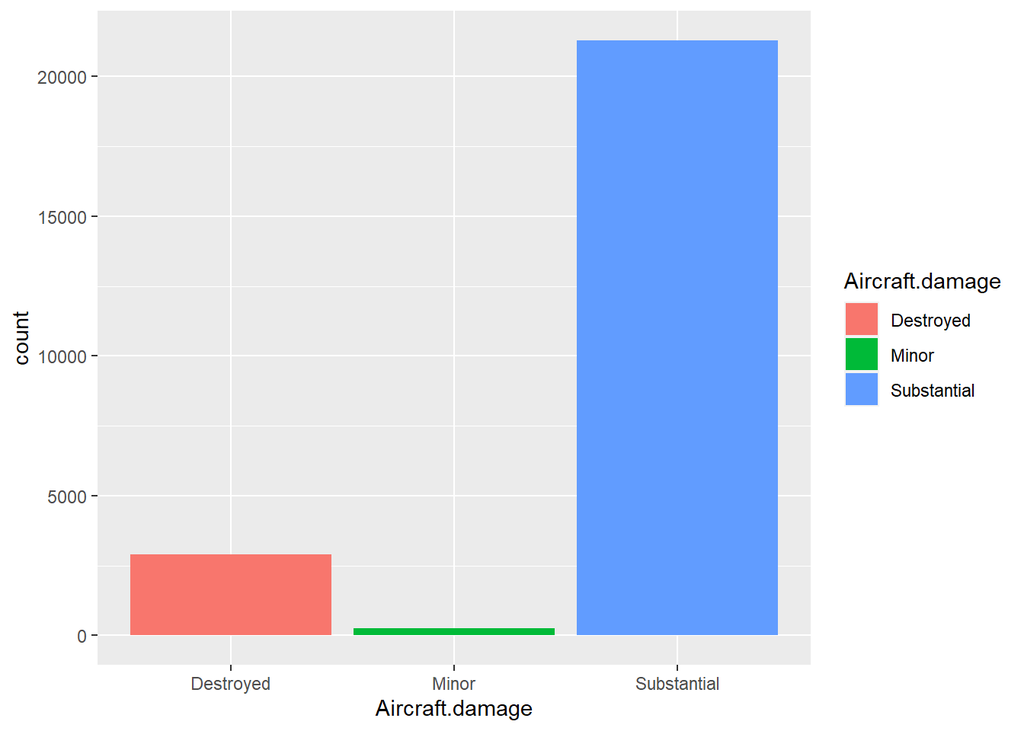

From the above plots we can see that the majority of incidents resulted in non-fatal injuries and substantial aircraft damage.

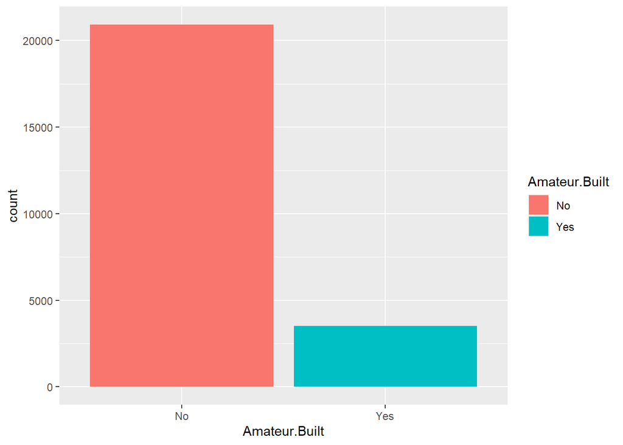

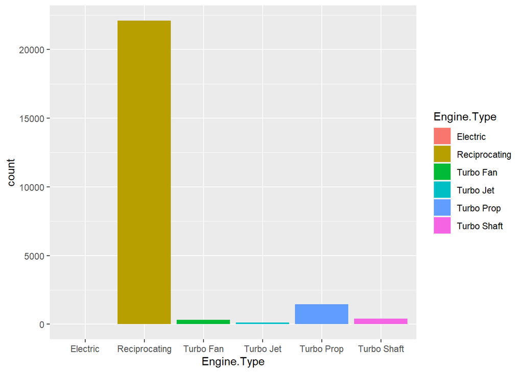

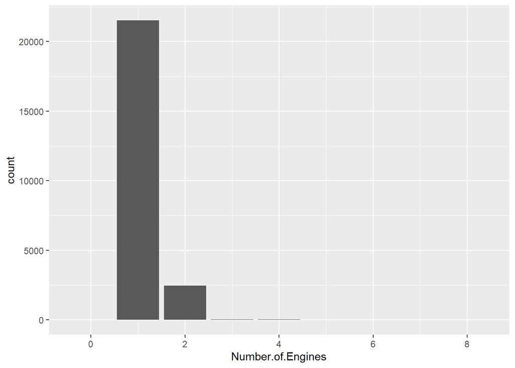

A substantial majority of incidents occurred in airplanes with a reciprocating engine and in airplanes with only one engine. These results are as expected since most small aircraft have 1 reciprocating engine.

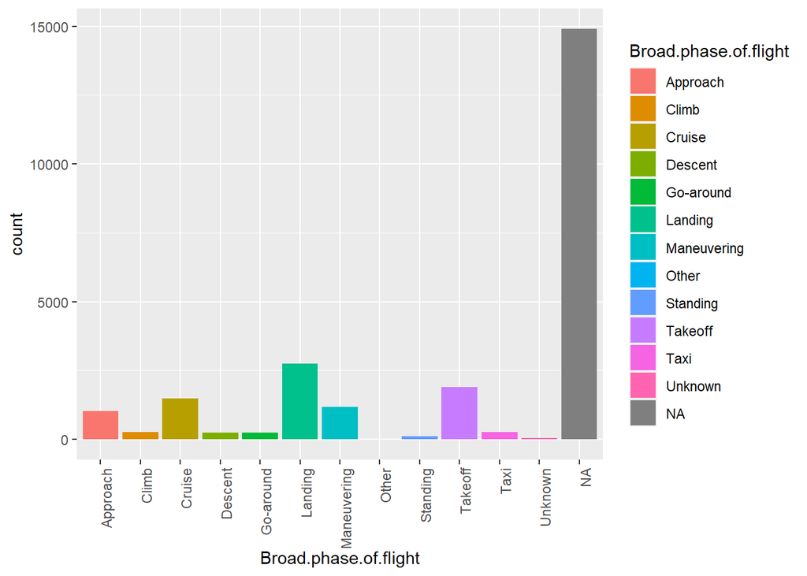

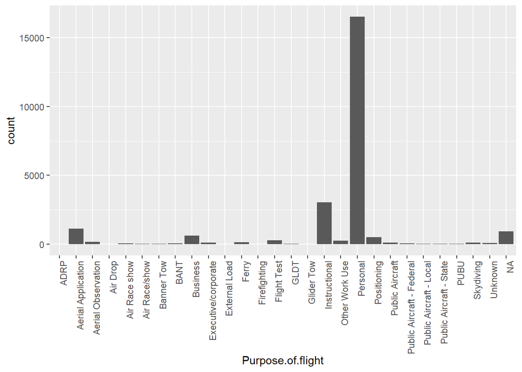

Here we see that most incidents occurred when the airplane was being used for personal use.

## Weather vs Fatal Injuries

Next, we will take a look at how weather affects the number of fatal injuries.

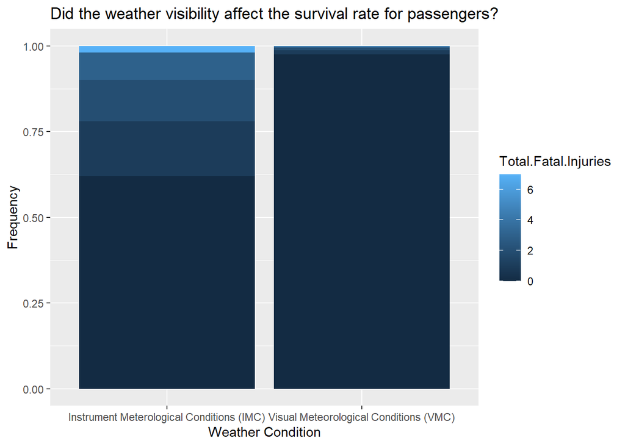

During the times that caused fatalities you can see that the pilots used IMC had a higher fatality than pilots that were controlling the plan themselves. In this case, was the error cased by the weather conditions or was it caused by pilot error or instrument error?

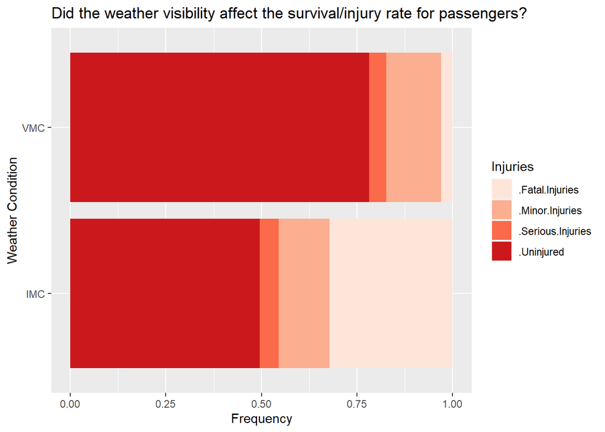

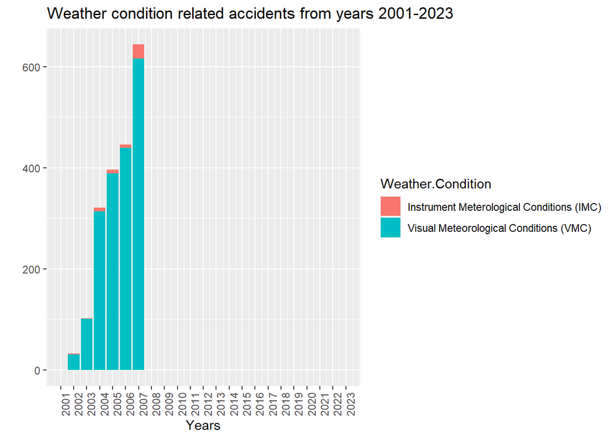

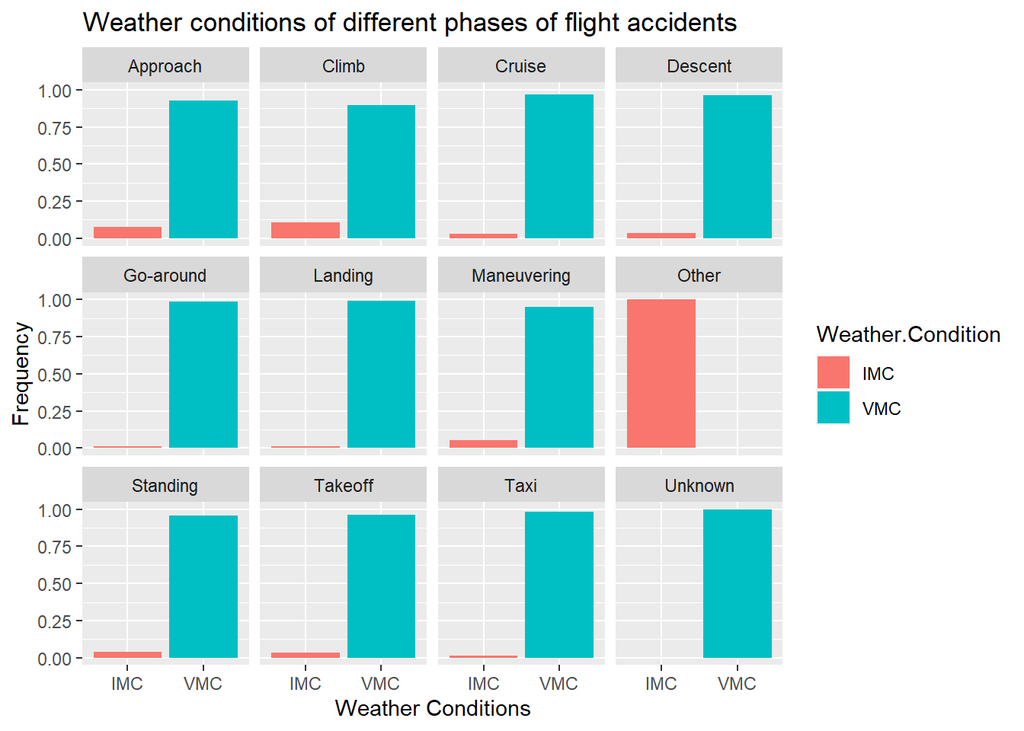

## Aircraft Characteristics vs Severity

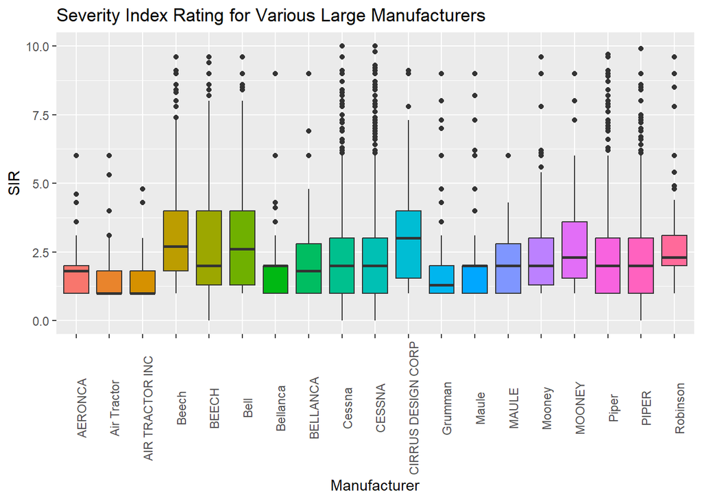

Beech, Cirrus, and Mooney tend to have more frequently severe accidents than other manufacturers.

# Conclusion/Findings